# P5

Simona Cernat

2022-10-15

```r
library(MASS)
library(class)
library(ISLR)
library(tidyverse)
set.seed(45)
```

1. Create a scatterplot of the Default dataset, where balance is mapped to the x position, income is mapped to the y position, and default is mapped to the colour. Can you see any interesting patterns already?

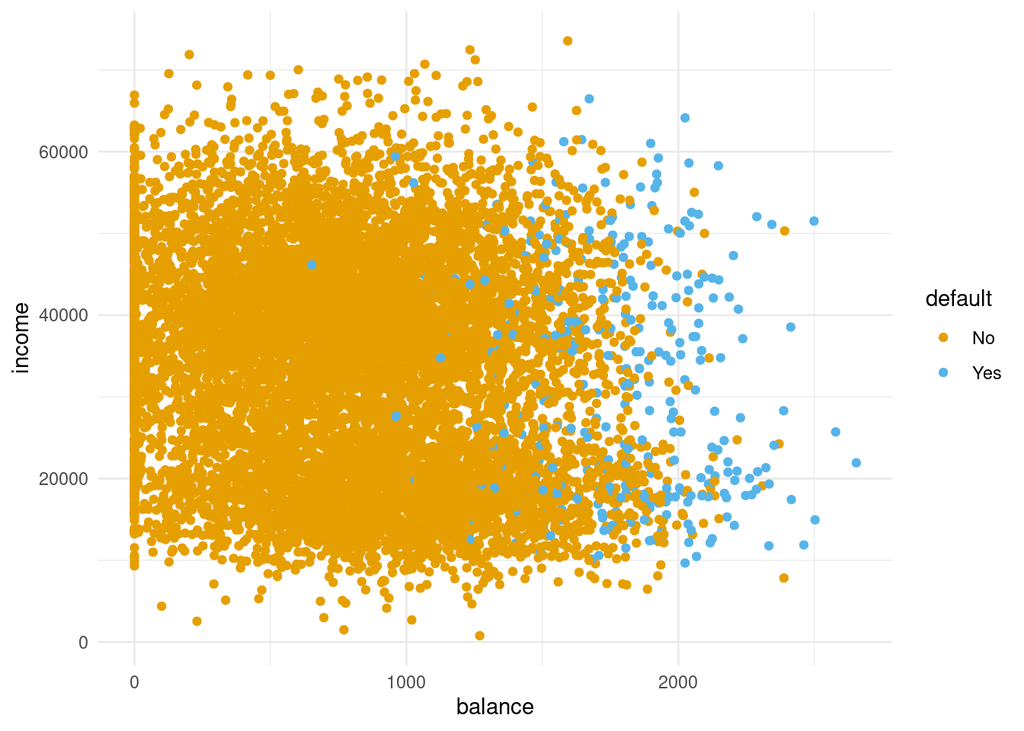

```r
plot <-Default %>%
  ggplot(aes(x = balance, y = income, color = default))+
  geom_point() +
  theme_minimal() +
  scale_color_manual(values=c( "#E69F00", "#56B4E9"))

plot
```

2. Add facet_grid(cols = vars(student)) to the plot. What do you see?

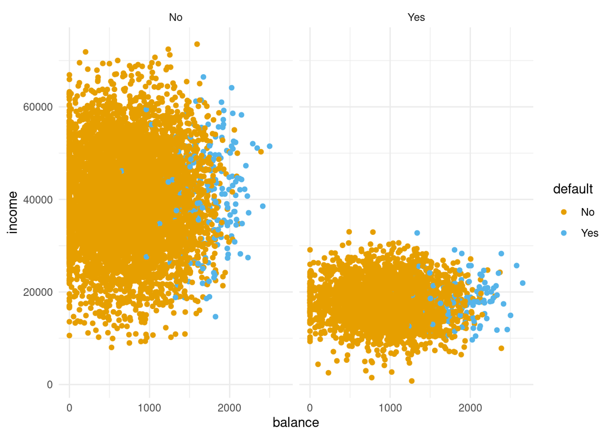

```r
plot + facet_grid(cols = vars(student))
```

3. Transform “student” into a dummy variable using ifelse() (0 = not a student, 1 = student). Then, randomly split the Default dataset into a training set default_train (80%) and a test set default_test (20%)

```r
default <- Default
default$id <- 1:nrow(Default)
default <- default %>%  mutate(student = ifelse(student == "Yes", 1, 0))
default_train <- default %>% dplyr::sample_frac(0.80)
default_test  <- dplyr::anti_join(default, default_train, by = 'id')

default_train <- default_train %>% select(-id)
default_test <-default_test %>% select(-id)
```

4. Create class predictions for the test set using the knn() function. Use student, balance, and income (but no basis functions of those variables) in the default_train dataset. Set k to 5. Store the predictions in a variable called knn_5_pred.

```r
knn_5_pred <- knn(
  train = default_train %>% select(-default),
  test  = default_test  %>% select(-default),
  cl    = as_factor(default_train$default),
  k     = 5
)
```

5. Create two scatter plots with income and balance as in the first plot you made. One with the true class (default) mapped to the colour aesthetic, and one with the predicted class (knn_5_pred) mapped to the colour aesthetic.

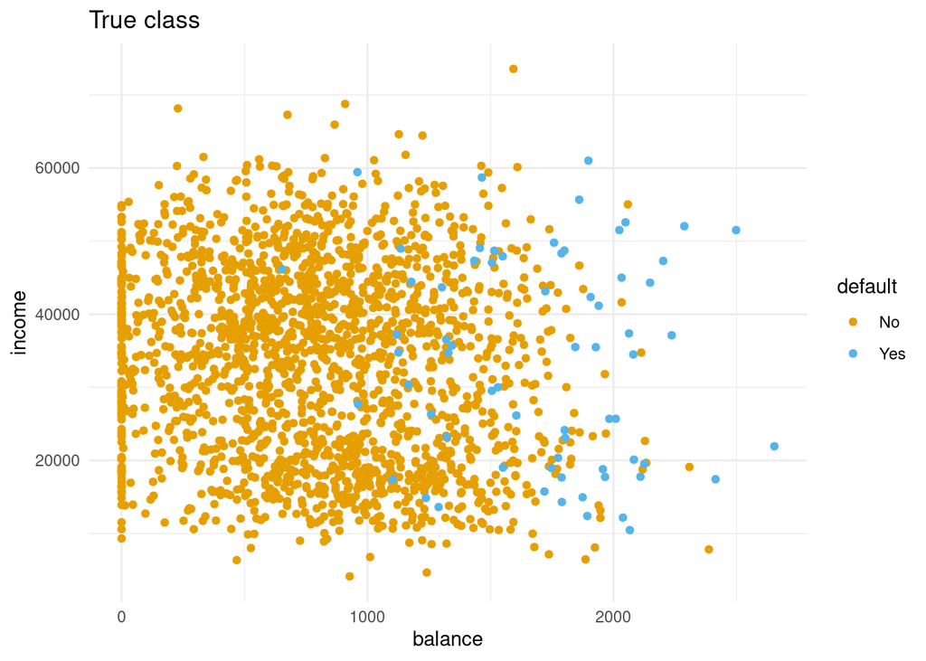

```r
default_test %>%
  arrange(default) %>%
  ggplot(aes(x = balance, y = income, colour = default)) +
  geom_point() +
  theme_minimal() +
  labs(title = "True class") +
  scale_color_manual(values=c( "#E69F00", "#56B4E9"))
```

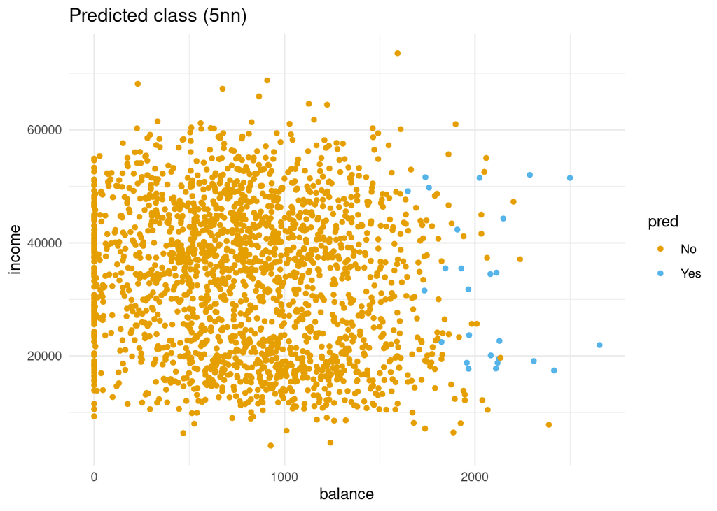

```r
bind_cols(default_test, pred = knn_5_pred) %>%
  ggplot(aes(x = balance, y = income, colour = pred)) +
  geom_point(size = 1.3) +
  scale_color_manual(values=c( "#E69F00", "#56B4E9")) +
  theme_minimal() +
  labs(title = "Predicted class (5nn)")
```

6. Repeat the same steps, but now with a knn_2_pred vector generated from a 2-nearest neighbours algorithm. Are there any differences?

```r
knn_2_pred <- knn(
  train = default_train %>% select(-default),
  test  = default_test  %>% select(-default),
  cl    = as_factor(default_train$default),
  k     = 2
)
```

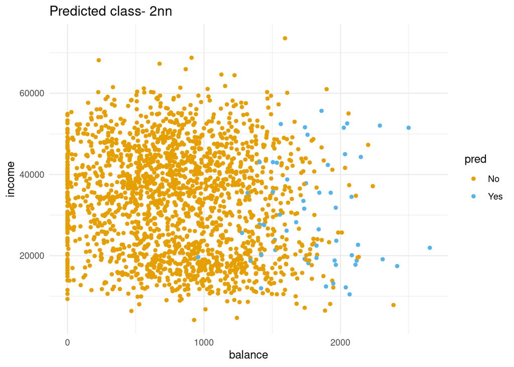

```r
bind_cols(default_test, pred = knn_2_pred) %>%
  ggplot(aes(x = balance, y = income, colour = pred)) +
  geom_point(size = 1.3) +
  scale_color_manual(values=c( "#E69F00", "#56B4E9")) +
  theme_minimal() +
  labs(title = "Predicted class- 2nn")
```

#There seems to be more false positives compared to knn-5.

7. What would this confusion matrix look like if the classification were perfect? # There would be only true positives and true negatives without false positives/negatives.
8. Make a confusion matrix for the 5-nn model and compare it to that of the 2-nn model. What do you conclude?

```r
table(true = default_test$default, predicted = knn_5_pred)
```

```
##      predicted
## true    No  Yes
##   No  1923   10
##   Yes   51   16
```

```r
table(true = default_test$default, predicted = knn_2_pred)
```

```
##      predicted
## true    No  Yes
##   No  1899   34
##   Yes   45   22
```

#Both classifiers have errors. The second one has a lower true negative but higher true positive compared to knn5.

9. Use glm() with argument family = binomial to fit a logistic regression model lr_mod to the default_train data.

```r
lr_mod <- glm(default ~ ., family = binomial, data = default_train)
```

Now we have generated a model, we can use the predict() method to output the estimated probabilities for each point in the training dataset. By default predict outputs the log-odds, but we can transform it back using the inverse logit function of before or setting the argument type = “response” within the predict function.

10. Visualise the predicted probabilities versus observed class for the training dataset in lr_mod. You can choose for yourself which type of visualisation you would like to make. Write down your interpretations along with your plot.

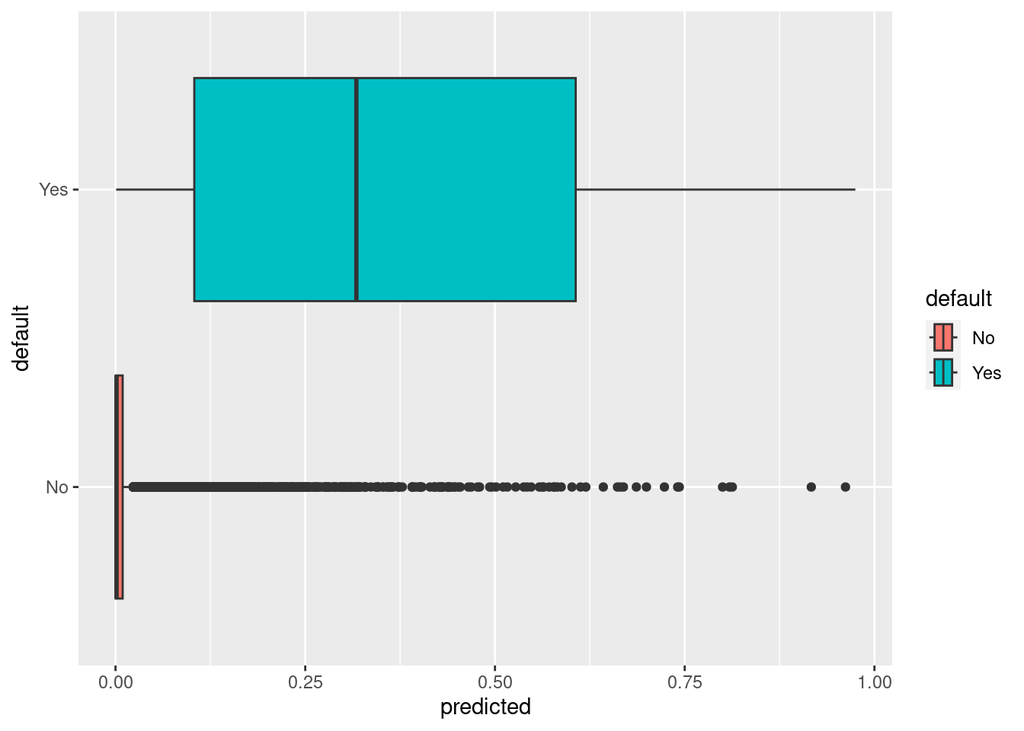

```r
predicted = predict(lr_mod)

default_train %>% mutate(predicted = predict(lr_mod, type = "response")) %>%
 ggplot(aes(x = predicted, y = default, fill = default)) +
  geom_boxplot()
```

There are still a lot of values with a high probability for default that were classified as “No”.

11.Look at the coefficients of the lr_mod model and interpret the coefficient for balance. What would the probability of default be for a person who is not a student, has an income of 40000, and a balance of 3000 dollars at the end of each month? Is this what you expect based on the plots we’ve made before?

```r
coefs <- coef(lr_mod)
coefs["balance"]
```

```
##     balance
## 0.006048276
```

```r
logodds <- coefs[1] + 40000*coefs[4] + 3000*coefs[3]
print(1 / (1 + exp(-logodds)))
```

```
## (Intercept)
##   0.9989901
```

12. Create a data frame called balance_df with 3 columns and 500 rows: student always 0, balance ranging from 0 to 3000, and income always the mean income in the default_train dataset.

```r
balance_df <- tibble(
  student = rep(0, 500),
  balance = seq(0, 3000, length.out = 500),
  income  = rep(mean(default_train$income), 500)
)
```

13. Use this dataset as the newdata in a predict() call using lr_mod to output the predicted probabilities for different values of balance. Then create a plot with the balance_df$balance variable mapped to x and the predicted probabilities mapped to y. Is this in line with what you expect?

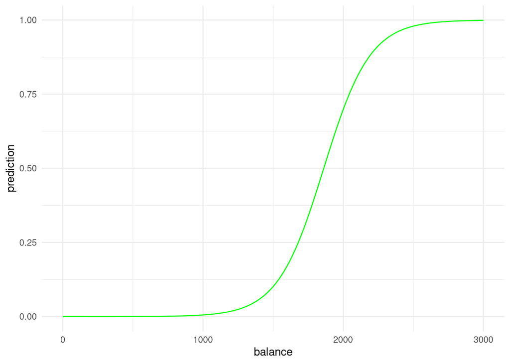

```r
balance_df['prediction'] <- predict(lr_mod, newdata = balance_df, type = "response")

balance_df %>%
  ggplot(aes(x = balance, y = prediction)) +
  geom_line(col = "green") +
  theme_minimal()
```

14. Create a confusion matrix just as the one for the KNN models by using a cutoff predicted probability of 0.5. Does logistic regression perform better?

```r
table(true = default_train$default, predicted = ifelse(predicted > 0.5, "Yes", "No"))
```

```
##      predicted
## true    No  Yes
##   No  7720   14
##   Yes  200   66
```

Train an LDA classifier lda_mod on the training set.

```r
lda_mod <- lda(default ~ ., data = default_train)
```

Look at the lda_mod object. What can you conclude about the characteristics of the people who default on their loans?

```r
lda_mod
```

```
## Call:
## lda(default ~ ., data = default_train)
##
## Prior probabilities of groups:
##      No     Yes
## 0.96675 0.03325
##
## Group means:
##       student   balance   income
## No  0.2922162  805.3601 33577.25
## Yes 0.3984962 1757.2081 31668.13
##
## Coefficients of linear discriminants:
##                   LD1
## student -1.397098e-01
## balance  2.245908e-03
## income   3.293756e-06
```

#By looking at the group means we can see that students have a higher p of defaulting. People who deafult have a higher balance. Income is on average equal between defaulters and faulters.

17. Create a confusion matrix and compare it to the previous methods.

```r
predict_lda <- predict(lda_mod, newdata = default_test)
table(true = default_test$default, predicted = predict_lda$class)
```

```
##      predicted
## true    No  Yes
##   No  1925    8
##   Yes   51   16
```

18. Create a model (using knn, logistic regression, or LDA) to predict whether a 14 year old boy from the 3rd class would have survived the Titanic disaster. You can find the data in the data/ folder. Would the passenger have survived if they were a girl in 2nd class?

```r
titanic <- read_csv("data/Titanic.csv")
lda_tittanic <- lda(Survived ~ Age * Sex * PClass, data = titanic)
```

```r
predict(lda_tittanic,
        newdata = tibble(
          PClass = c( "3rd",    "2nd"),
          Age    = c(    14,       14),
          Sex    = c("male", "female")
        ),
        type = "response"
)
```

```
## $class
## [1] 0 1
## Levels: 0 1
##
## $posterior
##           0         1
## 1 0.8827851 0.1172149
## 2 0.0438088 0.9561912
##
## $x
##          LD1
## 1 -0.7871361
## 2  2.0819376
```

#According to this model the boy has a 0.11 p of surviving and the girl’s is 0.95.